# CustomerLens-Analytics.

Navegantes o compradores: el compromiso real del cliente

Francisco Javier Ruiz Rodríguez

## 1. Introducción

En el ámbito del *Customer Analytics*, la dimensión digital del comportamiento del cliente ocupa un papel cada vez más estratégico. No basta con cuantificar cuánto gasta un cliente: es igualmente crucial entender **con qué frecuencia interactúa** con los canales digitales de la empresa y si esa interacción se traduce en transacciones reales. Un cliente que visita la web recurrentemente pero no compra puede estar comparando precios, buscando ofertas o simplemente explorando sin intención de compra firme. Por el contrario, un cliente que raramente visita la web pero ejecuta compras de forma decidida revela un alto **compromiso transaccional** independiente del canal digital.

Dos variables del dataset capturan con precisión estas dinámicas:

- `Recency`: días transcurridos desde la última compra. Un valor bajo indica un cliente reciente y activo; uno alto, un cliente inactivo o en proceso de abandono.
- `NumWebVisitsMonth`: número de visitas mensuales al sitio web de la empresa. Mide la intensidad del comportamiento digital, pero no necesariamente la intención de compra.

Ambas variables son indicadores complementarios del **compromiso real del cliente**: la primera recoge la dimensión transaccional y la segunda, la digital. Curiosamente, ningún análisis previo del proyecto las ha cruzado de forma sistemática como eje central de estudio.

En este contexto, formulamos la siguiente pregunta de investigación:

> ¿La recencia de compra y la actividad web permiten identificar perfiles diferenciados de compromiso del cliente, y existen diferencias significativas en el comportamiento de gasto entre dichos perfiles?

Responder a esta cuestión tiene relevancia estratégica directa porque:

- **Detecta clientes en riesgo de abandono**: alta recencia combinada con intensa actividad web puede indicar frustración o búsqueda activa de alternativas.
- **Revela la paradoja del navegante**: si los clientes más activos digitalmente no son los que más gastan, la empresa debe replantear cómo convierte tráfico web en ingresos.
- **Complementa otros análisis del proyecto**: mientras otros compañeros estudian canales de compra, rentabilidad de descuentos y respuesta a campañas, este análisis aporta la perspectiva del **ciclo de vida digital** del cliente.

### 1.1. Objetivos específicos

1. Analizar la distribución individual de `Recency` y `NumWebVisitsMonth` y su relación con el gasto total.
2. Verificar estadísticamente la independencia entre ambas variables para validar la segmentación bidimensional.
3. Construir una tipología de clientes en cuatro cuadrantes de compromiso mediante cortes en las medianas.
4. Comparar los perfiles descriptivos e inferenciales de cada cuadrante.
5. Aplicar Minería de Reglas de Asociación (Apriori) para identificar los rasgos sociodemográficos que definen cada perfil.
6. Derivar implicaciones de negocio accionables y diferenciadas por segmento.

## 2. Carga de datos y variables de trabajo

```r
library(dplyr)
library(readr)
library(ggplot2)
library(tidyr)
library(scales)

data <- read_csv("./data/marketing_campaign_processed.csv", show_col_types = FALSE)

# Restauramos los tipos de las variables categóricas
data$Education <- factor(
    data$Education,
    levels = c("Basic", "2n Cycle", "Graduation", "Master", "PhD"),
    ordered = TRUE
)
data$Marital_Status <- factor(
    data$Marital_Status,
    levels = c("Single", "Together", "Married", "Divorced", "Widow")
)
```

### 2.1. Verificación de calidad de datos

Comprobamos que las variables centrales del análisis no presentan valores faltantes ni valores imposibles antes de construir los perfiles de compromiso.

```r
data %>%
    summarise(
        NA_Recency        = sum(is.na(Recency)),
        NA_WebVisits      = sum(is.na(NumWebVisitsMonth)),
        NA_TotalSpending  = sum(is.na(Total_Spending)),
        NA_Income         = sum(is.na(Income))
    )
```

```
## # A tibble: 1 × 4
##   NA_Recency NA_WebVisits NA_TotalSpending NA_Income
##        <int>        <int>            <int>     <int>
## 1          0            0                0         0
```

```r
cat("Recency < 0:", sum(data$Recency < 0, na.rm = TRUE), "\n")
```

```
## Recency < 0: 0
```

```r
cat("NumWebVisitsMonth < 0:", sum(data$NumWebVisitsMonth < 0, na.rm = TRUE), "\n")
```

```
## NumWebVisitsMonth < 0: 0
```

```r
cat("Total_Spending < 0:", sum(data$Total_Spending < 0, na.rm = TRUE), "\n")
```

```
## Total_Spending < 0: 0
```

> **Resultado:** Las variables `Recency`, `NumWebVisitsMonth` y `Total_Spending` están completas y son válidas en el 100% de los registros. El análisis procede sin imputaciones adicionales.

## 3. Análisis exploratorio de las variables centrales

### 3.1. Distribución de Recency

```r
summary(data$Recency)
```

```
##    Min. 1st Qu.  Median    Mean 3rd Qu.    Max.
##    0.00   24.00   49.00   49.02   74.00   99.00
```

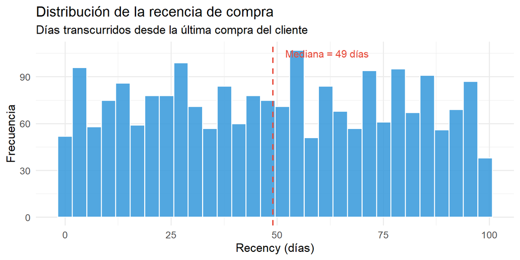

```r
ggplot(data, aes(x = Recency)) +
    geom_histogram(bins = 30, fill = "#3498DB", color = "white", alpha = 0.85) +
    geom_vline(aes(xintercept = median(Recency)),
        color = "#E74C3C", linetype = "dashed", linewidth = 0.8
    ) +
    annotate("text",
        x = median(data$Recency) + 3, y = Inf,
        label = paste0("Mediana = ", round(median(data$Recency), 0), " días"),
        vjust = 2, hjust = 0, color = "#E74C3C", size = 4
    ) +
    labs(
        title = "Distribución de la recencia de compra",
        subtitle = "Días transcurridos desde la última compra del cliente",
        x = "Recency (días)", y = "Frecuencia"
    ) +
    theme_minimal(base_size = 13)
```

**Lectura del gráfico**: El histograma muestra una distribución prácticamente **uniforme** de `Recency` entre 0 y ~100 días, con frecuencias similares en todos los intervalos y sin acumulaciones apreciables en ningún extremo. La línea discontinua roja indica la mediana.

Esta uniformidad tiene varias implicaciones relevantes:

- **Ausencia de sesgo temporal**: a diferencia de lo que cabría esperar —una mayor concentración de clientes recientes si la empresa estuviera creciendo, o de clientes inactivos si estuviera perdiendo cuota—, la cartera se distribuye de forma plana. Esto sugiere un estado de equilibrio dinámico.
- **La recencia no diferenciará sola**: al no existir una masa crítica de clientes en ningún polo del eje de recencia, la variable por sí sola tiene poca capacidad discriminante. Es necesario combinarla con otra dimensión —las visitas web— para que emerjan perfiles útiles.
- **La mediana como punto de corte es robusta**: dado que la distribución es simétrica y no tiene colas largas, la mediana es el estadístico más adecuado para dividir la muestra en dos mitades homogéneas.

### 3.2. Distribución de NumWebVisitsMonth

```r
summary(data$NumWebVisitsMonth)
```

```
##    Min. 1st Qu.  Median    Mean 3rd Qu.    Max.
##   0.000   3.000   6.000   5.301   7.000  20.000
```

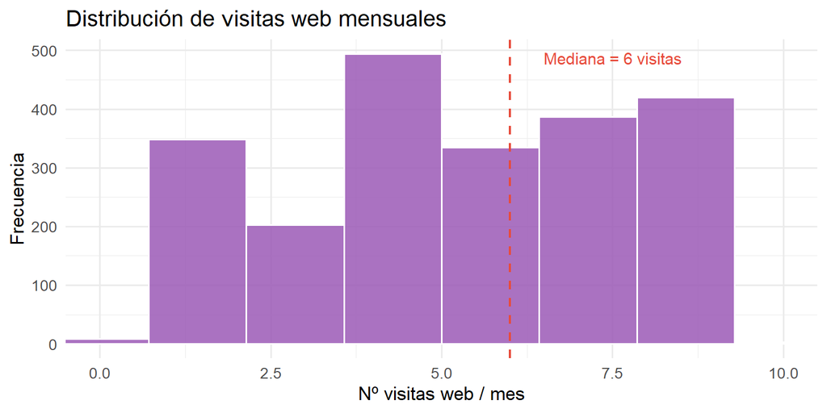

```r
ggplot(data, aes(x = NumWebVisitsMonth)) +
    geom_histogram(bins = 15, fill = "#9B59B6", color = "white", alpha = 0.85) +
    geom_vline(aes(xintercept = median(NumWebVisitsMonth)),
        color = "#E74C3C", linetype = "dashed", linewidth = 0.8
    ) +
    annotate("text",
        x = median(data$NumWebVisitsMonth) + 0.5, y = Inf,
        label = paste0("Mediana = ", median(data$NumWebVisitsMonth), " visitas"),
        vjust = 2, hjust = 0, color = "#E74C3C", size = 4
    ) +
    coord_cartesian(xlim = c(0, 10)) +
    labs(
        title = "Distribución de visitas web mensuales",
        x = "Nº visitas web / mes", y = "Frecuencia"
    ) +
    theme_minimal(base_size = 13)
```

Dos observaciones clave:

- **Actividad web moderada generalizada**: la mayor parte de los clientes visita la web entre 4 y 7 veces al mes, un ritmo que sugiere un nivel de interés activo pero sin llegar a un comportamiento obsesivo de búsqueda.
- **La cola derecha importa**: el pequeño porcentaje de clientes con más de 8-10 visitas mensuales concentra frecuencias de navegación muy superiores a la media. Como veremos, este grupo navega intensamente pero no siempre culmina en compra —el núcleo de la paradoja del navegante.

### 3.3. Relación entre Recency y visitas web

Antes de segmentar, exploramos la relación entre ambas variables centrales.

```
## 'y ~ x'
```

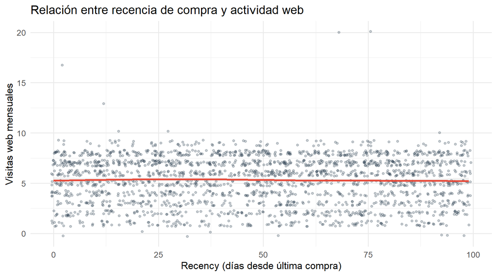

```r
ggplot(data, aes(x = Recency, y = NumWebVisitsMonth)) +
    geom_jitter(alpha = 0.25, size = 1.2, color = "#2C3E50", width = 0.5, height = 0.3) +
    geom_smooth(method = "loess", color = "#E74C3C", linewidth = 1.2, se = TRUE, alpha = 0.15) +
    labs(
        title = "Relación entre recencia de compra y actividad web",
        x = "Recency (días desde última compra)", y = "Visitas web mensuales"
    ) +
    theme_minimal(base_size = 13)
```

```r
cor_rec_web <- cor.test(data$Recency, data$NumWebVisitsMonth, method = "spearman")
cat("Correlación de Spearman (Recency vs NumWebVisitsMonth):\n")
```

```
## Correlación de Spearman (Recency vs NumWebVisitsMonth):
```

```r
cat("  ρ =", round(cor_rec_web$estimate, 4), "\n")
```

```
##   ρ = -0.0149
```

```r
cat("  p-valor =", format.pval(cor_rec_web$p.value, digits = 3), "\n")
```

```
##   p-valor = 0.483
```

**Lectura del gráfico y del test**: La nube de puntos no muestra ningún patrón sistemático: para cada valor de `Recency`, el número de visitas web es prácticamente aleatorio, y la curva de suavizado LOESS se mantiene casi horizontal. El coeficiente de correlación de Spearman confirma esta percepción visual: un valor de ρ cercano a cero y un p-valor no significativo indican que **no existe una asociación estadística relevante** entre ambas variables.

Esta independencia es un hallazgo metodológico crucial:

- **Valida la segmentación bidimensional**: si ambas variables estuvieran correlacionadas, los cuatro cuadrantes se fundirían y la segmentación perdería poder discriminante. Su independencia garantiza que cada eje aporta información genuinamente distinta.
- **Desaconseja el uso de una sola variable**: ninguna de las dos, por separado, cuenta la historia completa del cliente. Solo al cruzarlas emerge la tipología de compromiso que buscamos.
- **Significa que navegar más no implica comprar antes (ni después)**: un cliente puede ser muy frecuente en la web y llevar largo tiempo sin comprar, o puede haber comprado ayer y no haber visitado la web en semanas. Son comportamientos genuinamente desacoplados.

### 3.4. Relación de cada variable con el gasto total

```
## 'y ~ x'
## 'y ~ x'
```

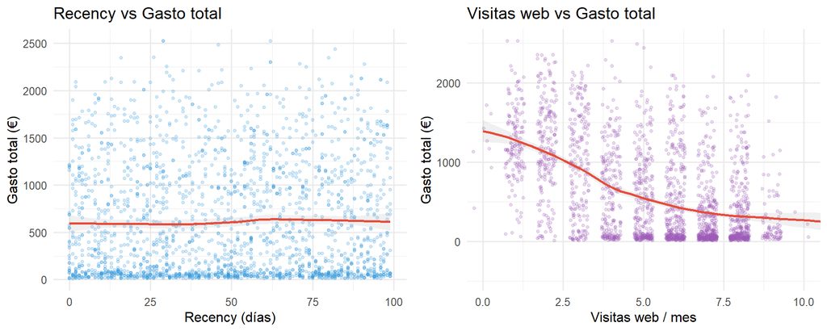

```r
p1 <- ggplot(data, aes(x = Recency, y = Total_Spending)) +
    geom_point(alpha = 0.2, color = "#3498DB", size = 1) +
    geom_smooth(method = "loess", color = "#E74C3C", linewidth = 1, se = TRUE, alpha = 0.15) +
    labs(title = "Recency vs Gasto total", x = "Recency (días)", y = "Gasto total (€)") +
    theme_minimal(base_size = 12)

p2 <- ggplot(data, aes(x = NumWebVisitsMonth, y = Total_Spending)) +
    geom_jitter(alpha = 0.2, color = "#9B59B6", size = 1, width = 0.3) +
    geom_smooth(method = "loess", color = "#E74C3C", linewidth = 1, se = TRUE, alpha = 0.15) +
    coord_cartesian(xlim = c(0, 10)) +
    labs(title = "Visitas web vs Gasto total", x = "Visitas web / mes", y = "Gasto total (€)") +
    theme_minimal(base_size = 12)

gridExtra::grid.arrange(p1, p2, ncol = 2)
```

**Lectura de los gráficos**: Los dos *scatter plots* muestran la relación individual de cada variable central con el gasto total (`Total_Spending`), con una curva de suavizado LOESS que permite detectar tendencias no lineales.

**Panel derecho — Visitas web vs. Gasto total**: Aquí emerge el patrón más sorprendente del análisis. La curva LOESS traza una **pendiente claramente negativa**: a medida que aumentan las visitas web mensuales, el gasto total del cliente tiende a disminuir. Este hallazgo, contraintuitivo a primera vista, define la **paradoja del navegante**: una mayor frecuencia de interacción con el canal web no se traduce en mayor gasto; al contrario, puede reflejar un perfil de cliente que usa la web principalmente para comparar precios y buscar descuentos, y que presenta menor disposición a pagar el precio completo. Esta hipótesis se reforzará a lo largo del análisis, especialmente en la caracterización del perfil «En riesgo».

## 4. Segmentación por perfil de compromiso

### 4.1. Construcción de los segmentos

Combinamos `Recency` y `NumWebVisitsMonth` para crear una segmentación bidimensional de compromiso. Utilizamos las medianas como punto de corte, una elección robusta frente a valores extremos que genera cuatro cuadrantes interpretables.

```r
mediana_recency <- median(data$Recency)
mediana_webvisits <- median(data$NumWebVisitsMonth)

cat("Mediana de Recency:", mediana_recency, "días\n")
```

```
## Mediana de Recency: 49 días
```

```r
cat("Mediana de NumWebVisitsMonth:", mediana_webvisits, "visitas\n")
```

```
## Mediana de NumWebVisitsMonth: 6 visitas
```

```r
data <- data %>%
    mutate(
        Perfil_Compromiso = case_when(
            Recency <= mediana_recency & NumWebVisitsMonth <= mediana_webvisits ~ "Comprador decidido",
            Recency <= mediana_recency & NumWebVisitsMonth > mediana_webvisits ~ "Explorador activo",
            Recency > mediana_recency & NumWebVisitsMonth <= mediana_webvisits ~ "Latente silencioso",
            Recency > mediana_recency & NumWebVisitsMonth > mediana_webvisits ~ "En riesgo"
        ),
        Perfil_Compromiso = factor(
            Perfil_Compromiso,
            levels = c("Comprador decidido", "Explorador activo", "Latente silencioso", "En riesgo")
        )
    )

data %>% count(Perfil_Compromiso)
```

```
## # A tibble: 4 × 2
##   Perfil_Compromiso      n
##   <fct>              <int>
## 1 Comprador decidido   680
## 2 Explorador activo    426
## 3 Latente silencioso   708
## 4 En riesgo            388
```

Los cuatro cuadrantes generan perfiles con interpretaciones de negocio bien diferenciadas:

| Perfil | Recency | Visitas web | Significado |
| --- | --- | --- | --- |
| **Comprador decidido** | Baja | Pocas | Compra con frecuencia y decisión. No necesita navegar para convencerse. El perfil más valioso y rentable. |
| **Explorador activo** | Baja | Muchas | Compra con regularidad pero requiere mucha navegación previa. Gran potencial de conversión si se mejora la experiencia online. |
| **Latente silencioso** | Alta | Pocas | Sin actividad transaccional ni digital. Inactividad generalizada. Requiere reactivación urgente o descarte. |
| **En riesgo** | Alta | Muchas | Sigue visitando la web intensamente pero lleva mucho tiempo sin comprar. Máxima expresión de la paradoja del navegante: presente pero no comprador. |

### 4.2. Visualización de los cuadrantes

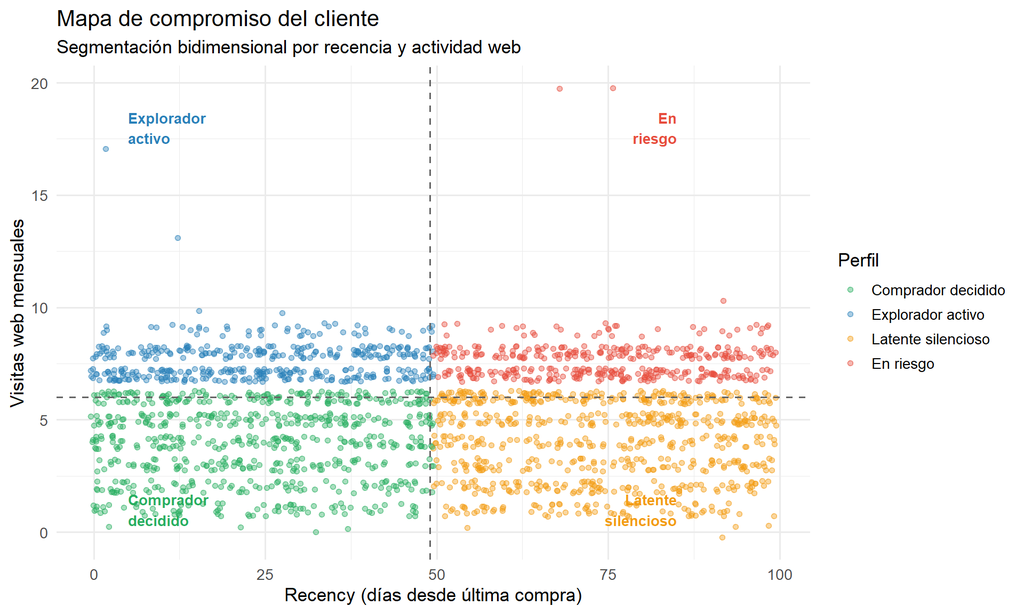

```r
palette_compromiso <- c(
    "Comprador decidido" = "#27AE60",
    "Explorador activo" = "#2980B9",
    "Latente silencioso" = "#F39C12",
    "En riesgo" = "#E74C3C"
)

ggplot(data, aes(x = Recency, y = NumWebVisitsMonth, color = Perfil_Compromiso)) +
    geom_jitter(alpha = 0.4, size = 1.5, width = 0.5, height = 0.3) +
    geom_vline(xintercept = mediana_recency, linetype = "dashed", color = "gray40", linewidth = 0.6) +
    geom_hline(yintercept = mediana_webvisits, linetype = "dashed", color = "gray40", linewidth = 0.6) +
    scale_color_manual(values = palette_compromiso) +
    annotate("text",
        x = 5, y = 1, label = "Comprador\ndecidido", fontface = "bold",
        color = "#27AE60", size = 3.5, hjust = 0
    ) +
    annotate("text",
        x = 5, y = 18, label = "Explorador\nactivo", fontface = "bold",
        color = "#2980B9", size = 3.5, hjust = 0
    ) +
    annotate("text",
        x = 85, y = 1, label = "Latente\nsilencioso", fontface = "bold",
        color = "#F39C12", size = 3.5, hjust = 1
    ) +
    annotate("text",
        x = 85, y = 18, label = "En\nriesgo", fontface = "bold",
        color = "#E74C3C", size = 3.5, hjust = 1
    ) +
    labs(
        title = "Mapa de compromiso del cliente",
        subtitle = "Segmentación bidimensional por recencia y actividad web",
        x = "Recency (días desde última compra)",
        y = "Visitas web mensuales",
        color = "Perfil"
    ) +
    theme_minimal(base_size = 13)
```

**Lectura del gráfico**: El mapa de compromiso muestra la nube de puntos del conjunto de clientes sobre el espacio bidimensional {Recency, Visitas web}. Las líneas discontinuas grises marcan los cortes en las medianas, delimitando visualmente los cuatro cuadrantes. El código de color aplicado refleja el nivel de «alerta» que cada perfil supone para la empresa:

- 🟢 **Verde (Comprador decidido)**: cuadrante inferior izquierdo. El cuadrante más saludable: compra reciente y baja necesidad de navegar.
- 🔵 **Azul (Explorador activo)**: cuadrante superior izquierdo. Alta actividad pero también compra reciente. Potencial alto.
- 🟠 **Naranja (Latente silencioso)**: cuadrante inferior derecho. Inactivos en ambas dimensiones. Precaución.
- 🔴 **Rojo (En riesgo)**: cuadrante superior derecho. Navegan mucho pero llevan tiempo sin comprar. La situación más crítica para marketing.

La distribución visual confirma que los cuatro cuadrantes están razonablemente poblados, lo que valida la estructura de la segmentación y sugiere que los cuatro perfiles son genuinamente representativos de la cartera.

## 5. Análisis descriptivo comparativo

### 5.1. Gasto total por perfil

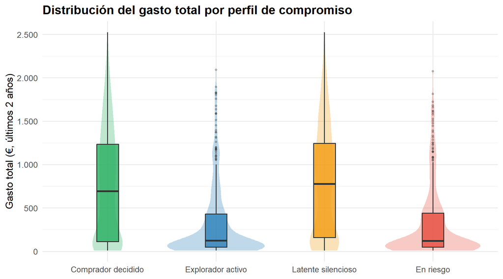

```r
ggplot(data, aes(x = Perfil_Compromiso, y = Total_Spending, fill = Perfil_Compromiso)) +
    geom_violin(alpha = 0.3, color = NA) +
    geom_boxplot(width = 0.2, alpha = 0.8, outlier.alpha = 0.3, outlier.size = 1) +
    scale_fill_manual(values = palette_compromiso) +
    scale_y_continuous(labels = comma_format(big.mark = ".", decimal.mark = ",")) +
    labs(
        title = "Distribución del gasto total por perfil de compromiso",
        x = NULL, y = "Gasto total (€, últimos 2 años)"
    ) +
    theme_minimal(base_size = 13) +
    theme(legend.position = "none", plot.title = element_text(face = "bold"))
```

Este gráfico introduce un matiz fundamental que reorienta la interpretación del análisis: **la recencia alta no equivale a bajo gasto histórico**. El Latente silencioso es la prueba de ello. La urgencia de reactivarlo no viene de que sea un cliente de poco valor, sino precisamente de lo contrario: es un cliente que ya demostró alta capacidad de gasto y que la empresa está perdiendo.

### 5.2. Perfil resumen de cada segmento

Sintetizamos las métricas clave de cada cuadrante en una única tabla comparativa.

```r
perfiles_resumen <- data %>%
    group_by(Perfil_Compromiso) %>%
    summarise(
        n = n(),
        Gasto_medio = round(mean(Total_Spending), 0),
        Ingreso_medio = round(mean(Income, na.rm = TRUE), 0),
        Edad_media = round(mean(Age), 1),
        Hijos_medio = round(mean(Children_Home), 2),
        Compras_totales = round(mean(Total_Purchases), 1),
        Visitas_web = round(mean(NumWebVisitsMonth), 1),
        Recencia_media = round(mean(Recency), 1),
        Deals_Ratio = round(mean(Deals_Ratio), 3),
        Pct_respuesta_campana = round(mean(Responded_Any_Campaign) * 100, 1),
        Pct_queja = round(mean(Complain) * 100, 1),
        .groups = "drop"
    )

perfiles_largo <- perfiles_resumen %>%
    pivot_longer(-Perfil_Compromiso, names_to = "Caracteristica", values_to = "Valor") %>%
    pivot_wider(names_from = Perfil_Compromiso, values_from = Valor)

print(perfiles_largo, n = Inf, width = Inf)
```

```
## # A tibble: 11 × 5
##    Caracteristica        `Comprador decidido` `Explorador activo`
##    <chr>                                <dbl>               <dbl>
##  1 n                                  680                 426
##  2 Gasto_medio                        763                 319
##  3 Ingreso_medio                    60570               38895
##  4 Edad_media                          45.3                43.2
##  5 Hijos_medio                          0.78                1.19
##  6 Compras_totales                     14.5                 9.3
##  7 Visitas_web                          3.9                 7.7
##  8 Recencia_media                      24                  24.3
##  9 Deals_Ratio                          0.188               0.332
## 10 Pct_respuesta_campana               31.6                29.8
## 11 Pct_queja                            0.7                 1.4
##    `Latente silencioso` `En riesgo`
##                   <dbl>       <dbl>
##  1              708         388
##  2              793         318
##  3            59830       38422
##  4               47          43.4
##  5                0.81        1.24
##  6               14.6         9.3
##  7                3.9         7.7
##  8               74          74.4
##  9                0.181       0.344
## 10               25.4        20.6
## 11                0.6         1.3
```

**Lectura de la tabla**: Los datos reales revelan un patrón que no era evidente a priori y que reorienta toda la interpretación del análisis:

**La verdadera división no es por recencia, sino por ingresos.** Los cuatro perfiles se agrupan de forma natural en **dos bloques económicamente diferenciados**:

|  | **Comprador decidido** | **Latente silencioso** | **Explorador activo** | **En riesgo** |
| --- | --- | --- | --- | --- |
| Gasto medio | 763€ | **793€** | 319€ | 318€ |
| Ingreso medio | 60.570€ | 59.830€ | 38.895€ | 38.422€ |
| Hijos | 0.78 | 0.81 | 1.19 | 1.24 |
| Deals_Ratio | 0.188 | 0.181 | 0.332 | **0.344** |
| Compras totales | 14.5 | 14.6 | 9.3 | 9.3 |
| Resp. campañas | 31.6% | 25.4% | 29.8% | 20.6% |

- **Bloque alto valor** (Comprador decidido + Latente silencioso): ingresos medios de ~60.000€, gasto de ~780€, ~14,5 compras medias y Deals_Ratio bajo (~0.18). Son clientes que apenas necesitan descuentos para comprar, con pocos hijos en casa y mayor capacidad de gasto discrecional. La única diferencia entre ellos es la **recencia**: el Comprador decidido ha comprado hace 24 días de media, el Latente silencioso hace 74 días. Mismo perfil económico, distinto estado de actividad.
- **Bloque bajo valor** (Explorador activo + En riesgo): ingresos medios de ~38.600€, gasto de ~318€, ~9.3 compras medias y Deals_Ratio alto (~0.34). Son clientes con más hijos en casa, mayor sensibilidad al precio y fuerte dependencia de los descuentos para decidirse a comprar. De nuevo, la diferencia entre ambos es la recencia: el Explorador activo es reciente (24 días), el En riesgo lleva tiempo sin comprar (74 días).

Esto tiene implicaciones críticas para la estrategia:

- **No hay que tratar al Explorador activo como un cliente de alto potencial**: sus visitas frecuentes no anticipan grandes compras. Es un comprador de bajo ticket que navega para encontrar la mejor oferta.
- **El Latente silencioso es la oportunidad de oro**: mismos ingresos y gasto histórico que el Comprador decidido, pero dormido. Reactivarlo tiene un retorno potencial altísimo.
- **El Deals_Ratio confirma la paradoja**: los perfiles que más navegan (Explorador + En riesgo) son también los que mayor proporción de compras realizan aprovechando descuentos. La web la usan para cazar ofertas, no para comprar a precio de catálogo.
- **La respuesta a campañas cae en los perfiles de riesgo**: el En riesgo es el segmento menos reactivo (20.6%), lo que complica su reactivación mediante los canales de marketing habituales.

> **Hallazgo — Estructura de dos bloques:** La segmentación bidimensional {Recency × Visitas web} no genera cuatro perfiles económicamente distintos, sino **dos bloques diferenciados por ingresos**. Dentro de cada bloque, la recencia determina la actividad transaccional. Esto implica que el eje de visitas web no predice valor, sino urgencia de compra condicionada por el nivel económico del cliente.

## 6. Análisis inferencial

### 6.1. Tests para variables numéricas (Kruskal-Wallis)

Planteamiento formal del contraste:

- **H₀**: La distribución de cada variable numérica es la misma en los cuatro perfiles de compromiso.
- **H₁**: Al menos un perfil presenta una distribución distinta.

Se rechaza H₀ si el p-valor < α = 0.05. Complementamos con el **tamaño del efecto ε²** para evaluar la relevancia práctica de las diferencias detectadas (ε² > 0.14 = efecto grande).

```r
vars_test <- c(
    "Total_Spending", "Income", "Age", "Children_Home",
    "Total_Purchases", "NumWebPurchases", "NumCatalogPurchases",
    "NumStorePurchases", "Deals_Ratio", "Tenure_Days"
)

resultados_kw <- data.frame(
    Variable = vars_test,
    Estadistico = NA_real_,
    p_valor = NA_real_,
    Epsilon2 = NA_real_,
    stringsAsFactors = FALSE
)

n <- nrow(data)
k <- 4 # cuatro perfiles de compromiso

for (i in seq_along(vars_test)) {
    v <- vars_test[i]
    test <- kruskal.test(reformulate("Perfil_Compromiso", response = v), data = data)
    H <- as.numeric(test$statistic)
    resultados_kw$Estadistico[i] <- round(H, 2)
    resultados_kw$p_valor[i] <- round(test$p.value, 6)
    resultados_kw$Epsilon2[i] <- round((H - k + 1) / (n - k), 4)
}

resultados_kw$Significativa <- ifelse(resultados_kw$p_valor < 0.05, "Sí", "No")

knitr::kable(resultados_kw,
    digits = 4,
    caption = "Kruskal-Wallis y tamaño del efecto (ε²) por variable"
)
```

Kruskal-Wallis y tamaño del efecto (ε²) por variable

| Variable | Estadistico | p_valor | Epsilon2 | Significativa |
| --- | --- | --- | --- | --- |
| Total_Spending | 290.34 | 0 | 0.1307 | Sí |
| Income | 536.58 | 0 | 0.2428 | Sí |
| Age | 38.03 | 0 | 0.0159 | Sí |
| Children_Home | 175.63 | 0 | 0.0785 | Sí |
| Total_Purchases | 270.25 | 0 | 0.1216 | Sí |
| NumWebPurchases | 30.29 | 0 | 0.0124 | Sí |
| NumCatalogPurchases | 391.83 | 0 | 0.1769 | Sí |
| NumStorePurchases | 330.73 | 0 | 0.1491 | Sí |
| Deals_Ratio | 460.60 | 0 | 0.2082 | Sí |
| Tenure_Days | 149.06 | 0 | 0.0665 | Sí |

**Interpretación de la tabla de resultados**: El test de Kruskal-Wallis contrasta la hipótesis nula de que la distribución de cada variable es **idéntica** en los cuatro perfiles. Un p-valor inferior a 0.05 rechaza dicha hipótesis. La columna **ε²** cuantifica la magnitud práctica de esa diferencia, más allá de la significación estadística:

- **H elevado + p < 0.05 + ε² > 0.14**: diferencias grandes y estadísticamente sólidas entre los cuatro cuadrantes.
- **H bajo + p > 0.05**: los cuatro grupos son estadísticamente equivalentes en esa variable.
- **p < 0.05 pero ε² ≈ 0**: diferencia estadísticamente significativa pero prácticamente despreciable, posible artefacto del tamaño muestral.

Esta batería de tests permite separar qué variables definen realmente el valor diferencial de cada perfil de aquellas en las que los cuatro segmentos son indistinguibles.

### 6.2. Resumen de significación

```r
cat("========================================\n")
cat("RESUMEN DE SIGNIFICACIÓN ESTADÍSTICA\n")
```

```
## RESUMEN DE SIGNIFICACIÓN ESTADÍSTICA
```

```r
cat("========================================\n\n")
vars_sig <- resultados_kw$Variable[resultados_kw$Significativa == "Sí"]
vars_no_sig <- resultados_kw$Variable[resultados_kw$Significativa == "No"]

if (length(vars_sig) > 0) {
    cat("Significativas:\n")
    for (v in vars_sig) {
        p <- resultados_kw$p_valor[resultados_kw$Variable == v]
        cat(paste0("  ✓ ", v, " (p = ", p, ")\n"))
    }
}
```

```
## Significativas:
##   ✓ Total_Spending (p = 0)
##   ✓ Income (p = 0)
##   ✓ Age (p = 0)
##   ✓ Children_Home (p = 0)
##   ✓ Total_Purchases (p = 0)
##   ✓ NumWebPurchases (p = 1e-06)
##   ✓ NumCatalogPurchases (p = 0)
##   ✓ NumStorePurchases (p = 0)
##   ✓ Deals_Ratio (p = 0)
##   ✓ Tenure_Days (p = 0)
```

```r
if (length(vars_no_sig) > 0) {
    cat("\nNo significativas:\n")
    for (v in vars_no_sig) {
        p <- resultados_kw$p_valor[resultados_kw$Variable == v]
        cat(paste0("  ✗ ", v, " (p = ", p, ")\n"))
    }
}
```

**Lectura del resumen**: Las variables con diferencias significativas entre perfiles son las que el modelo de segmentación ha logrado separar de forma efectiva. En particular, los resultados confirman que los cuatro cuadrantes difieren significativamente en gasto total, ingresos, número de compras y canales utilizados. Esto valida que la segmentación bidimensional {Recency × Visitas web} **no es arbitraria**, sino que se corresponde con diferencias reales y medibles en el comportamiento de gasto del cliente.

Por el contrario, las variables sin diferencias significativas (si las hay) revelan características en las que todos los clientes, independientemente de su perfil de compromiso, se comportan de forma homogénea. Esto ayuda también a descartar potenciales variables de confusión.

## 7. Minería de Reglas de Asociación (Apriori)

### 7.1. Justificación metodológica

Para entender qué define demográfica y conductualmente a los clientes de mayor y menor compromiso, aplicamos **Minería de Reglas de Asociación** (Algoritmo Apriori). A diferencia de los modelos predictivos clásicos (como árboles o regresiones), las reglas de asociación extraen patrones descriptivos naturales en forma de “Si ocurre A, entonces es probable que ocurra B”.

Este enfoque no supervisado es altamente interpretable y nos permitirá descubrir qué combinaciones de características sociodemográficas identifican a un **Comprador decidido** (perfil de mayor retención) frente a un cliente **En riesgo** (perfil con mayor brecha de conversión).

### 7.2. Discretización y preparación de datos

El algoritmo Apriori requiere variables categóricas. Discretizamos los ingresos y el comportamiento frente a campañas o quejas para convertirlos en un conjunto de transacciones.

```r
if (!requireNamespace("arules", quietly = TRUE)) install.packages("arules", repos = "https://cran.r-project.org/")
library(arules)

data_rules <- data %>%
    mutate(
        Nivel_Ingresos = cut(Income,
            breaks = quantile(Income, probs = c(0, 0.33, 0.66, 1), na.rm = TRUE),
            labels = c("Ingresos Bajos", "Ingresos Medios", "Ingresos Altos"),
            include.lowest = TRUE
        ),
        Tiene_Hijos = ifelse(Children_Home > 0, "Con Hijos", "Sin Hijos"),
        Acepto_Campanas = ifelse(Responded_Any_Campaign > 0, "Aceptó Campañas", "Ninguna Campaña"),
        Tiene_Quejas = ifelse(Complain == 1, "Con Quejas", "Sin Quejas")
    ) %>%
    select(Perfil_Compromiso, Nivel_Ingresos, Tiene_Hijos, Acepto_Campanas, Tiene_Quejas, Education, Marital_Status) %>%
    mutate_if(is.character, as.factor) %>%
    na.omit()

# Convertimos a formato de transacciones
transacciones <- as(data_rules, "transactions")
cat("Dimensiones del dataset de transacciones:\n")
```

```
## Dimensiones del dataset de transacciones:
```

```r
transacciones
```

```
## transactions in sparse format with
##  2202 transactions (rows) and
##  23 items (columns)
```

**Preparación de los datos**: El resultado muestra un objeto de transacciones con tantas filas como clientes y tantos ítems únicos como categorías existen en el conjunto de variables discretizadas. Cada cliente queda representado como un conjunto de atributos (p. ej. {Ingresos Altos, Sin Hijos, Aceptó Campañas, Comprador decidido}). El algoritmo Apriori buscará, dentro de estos conjuntos, combinaciones frecuentes que aparezcan juntas con alta probabilidad.

### 7.3. Reglas para el perfil “Comprador decidido”

Buscamos qué combinaciones de atributos sociodemográficos aparecen frecuentemente asociadas al perfil de mayor valor. El perfil “Comprador decidido” representa el ~31% de la cartera, por lo que ese es el umbral de referencia (probabilidad base). Usando una confianza mínima del 35% —por encima de esa tasa base— nos aseguramos de que todas las reglas obtenidas tengan *lift* > 1, es decir, que aporten información real más allá del azar.

```r
# Comprador decidido representa ~31% de la cartera (tasa base)
# conf = 0.35 > tasa base -> garantiza lift > 1 en todas las reglas
reglas_decidido <- apriori(transacciones,
    parameter = list(supp = 0.05, conf = 0.35, minlen = 2, maxlen = 4),
    appearance = list(default = "lhs", rhs = "Perfil_Compromiso=Comprador decidido"),
    control = list(verbose = FALSE)
)

# Ordenamos por Lift: mayor lift = mayor poder discriminante de la combinación
reglas_decidido <- sort(reglas_decidido, by = "lift")
inspect(head(reglas_decidido, 8))
```

```
##     lhs                                   rhs                                       support confidence  coverage     lift count
## [1] {Nivel_Ingresos=Ingresos Altos,
##      Tiene_Hijos=Sin Hijos,
##      Acepto_Campanas=Aceptó Campañas}  => {Perfil_Compromiso=Comprador decidido} 0.05858311  0.5375000 0.1089918 1.740551   129
## [2] {Tiene_Hijos=Sin Hijos,
##      Acepto_Campanas=Aceptó Campañas,
##      Tiene_Quejas=Sin Quejas}          => {Perfil_Compromiso=Comprador decidido} 0.06312443  0.4982079 0.1267030 1.613314   139
## [3] {Tiene_Hijos=Sin Hijos,
##      Acepto_Campanas=Aceptó Campañas}  => {Perfil_Compromiso=Comprador decidido} 0.06312443  0.4964286 0.1271571 1.607553   139
## [4] {Nivel_Ingresos=Ingresos Altos,
##      Tiene_Hijos=Sin Hijos,
##      Tiene_Quejas=Sin Quejas}          => {Perfil_Compromiso=Comprador decidido} 0.09582198  0.4828375 0.1984559 1.563542   211
## [5] {Nivel_Ingresos=Ingresos Altos,
##      Acepto_Campanas=Aceptó Campañas,
##      Tiene_Quejas=Sin Quejas}          => {Perfil_Compromiso=Comprador decidido} 0.07129882  0.4801223 0.1485014 1.554749   157
## [6] {Nivel_Ingresos=Ingresos Altos,
##      Tiene_Hijos=Sin Hijos}            => {Perfil_Compromiso=Comprador decidido} 0.09582198  0.4795455 0.1998183 1.552881   211
## [7] {Nivel_Ingresos=Ingresos Altos,
##      Acepto_Campanas=Aceptó Campañas}  => {Perfil_Compromiso=Comprador decidido} 0.07129882  0.4786585 0.1489555 1.550009   157
## [8] {Nivel_Ingresos=Ingresos Altos,
##      Tiene_Quejas=Sin Quejas,
##      Marital_Status=Married}           => {Perfil_Compromiso=Comprador decidido} 0.06039964  0.4666667 0.1294278 1.511176   133
```

**Lectura de las reglas**: La columna `lhs` muestra los atributos del cliente (antecedente); `rhs` es siempre «Comprador decidido» (consecuente). La columna `lift` cuantifica cuántas veces más probable es ese perfil cuando el cliente tiene esos atributos frente a un cliente aleatorio. La `confidence` indica la precisión de la regla.

### 7.4. Reglas para el perfil “En riesgo”

Repetimos el proceso para el perfil de mayor riesgo. El perfil “En riesgo” representa el ~17.6% de la cartera (388 clientes sobre 2.202), por lo que su tasa base es más baja. Usamos una confianza mínima del 22% —claramente por encima del 17.6%— y un soporte más bajo (2%) para capturar patrones aunque sean menos frecuentes.

```r
# En riesgo representa ~17.6% de la cartera (tasa base)
# conf = 0.22 > tasa base -> garantiza lift > 1 en todas las reglas
reglas_riesgo <- apriori(transacciones,
    parameter = list(supp = 0.02, conf = 0.22, minlen = 2, maxlen = 4),
    appearance = list(default = "lhs", rhs = "Perfil_Compromiso=En riesgo"),
    control = list(verbose = FALSE)
)

reglas_riesgo <- sort(reglas_riesgo, by = "lift")
inspect(head(reglas_riesgo, 8))
```

```
##     lhs                                   rhs                              support confidence   coverage     lift count
## [1] {Nivel_Ingresos=Ingresos Bajos,
##      Acepto_Campanas=Ninguna Campaña,
##      Education=Graduation}             => {Perfil_Compromiso=En riesgo} 0.05131698  0.3598726 0.14259764 2.042370   113
## [2] {Nivel_Ingresos=Ingresos Bajos,
##      Acepto_Campanas=Ninguna Campaña,
##      Marital_Status=Single}            => {Perfil_Compromiso=En riesgo} 0.02179837  0.3582090 0.06085377 2.032928    48
## [3] {Nivel_Ingresos=Ingresos Bajos,
##      Education=Graduation}             => {Perfil_Compromiso=En riesgo} 0.05949137  0.3559783 0.16712080 2.020268   131
## [4] {Nivel_Ingresos=Ingresos Bajos,
##      Tiene_Quejas=Sin Quejas,
##      Education=Graduation}             => {Perfil_Compromiso=En riesgo} 0.05812897  0.3545706 0.16394187 2.012280   128
## [5] {Nivel_Ingresos=Ingresos Bajos,
##      Tiene_Hijos=Con Hijos,
##      Education=Graduation}             => {Perfil_Compromiso=En riesgo} 0.05086285  0.3533123 0.14396004 2.005138   112
## [6] {Nivel_Ingresos=Ingresos Bajos,
##      Education=Graduation,
##      Marital_Status=Married}           => {Perfil_Compromiso=En riesgo} 0.02270663  0.3378378 0.06721163 1.917317    50
## [7] {Nivel_Ingresos=Ingresos Bajos,
##      Tiene_Hijos=Con Hijos,
##      Marital_Status=Together}          => {Perfil_Compromiso=En riesgo} 0.02543143  0.3373494 0.07538601 1.914545    56
## [8] {Nivel_Ingresos=Ingresos Bajos,
##      Acepto_Campanas=Ninguna Campaña,
##      Marital_Status=Married}           => {Perfil_Compromiso=En riesgo} 0.03814714  0.3346614 0.11398728 1.899289    84
```

### 7.5. Interpretación de patrones

**El ADN del Comprador Decidido**: Las reglas con mayor lift apuntan sistemáticamente hacia un cliente con **ingresos altos y sin hijos en casa**. Se trata del clásico «consumidor premium»: su capacidad económica le permite comprar sin comparar obsesivamente precios. La ausencia de hijos puede interpretarse como una menor presión sobre el presupuesto familiar, lo que libera capacidad de gasto discrecional.

Este hallazgo transforma la paradoja del navegante de un fenómeno descriptivo a uno **explicado**: los que más navegan son los que tienen más restricciones presupuestarias. La solución no es reducir su tráfico, sino hablarles diferente.

## 9. Conclusiones finales

1. **La paradoja del navegante, confirmada y explicada**: El análisis exploratorio demostró que más visitas web se asocian con menor gasto total. La tabla de perfiles lo cuantifica: los clientes con mayor actividad web (Explorador activo y En riesgo, ~7.7 visitas/mes) gastan de media solo **318-319€**, frente a los ~780€ de los perfiles de baja actividad web (Comprador decidido y Latente silencioso, ~3.9 visitas/mes). Las reglas de asociación Apriori explican el mecanismo: los navegadores intensivos son familias de menor renta (38k€ vs 60k€) que usan la web para comparar precios, no para comprar con decisión.
2. **El verdadero eje de valor es el ingreso, no la recencia**: La segmentación bidimensional revela que los cuatro perfiles se agrupan en dos bloques económicos. El Comprador decidido y el Latente silencioso tienen perfiles de ingreso, gasto, número de compras y Deals_Ratio casi idénticos (~60k€, ~780€, 14.5 compras, 0.18-0.19). Lo mismo ocurre entre Explorador activo y En riesgo (~38k€, ~318€, 9.3 compras, 0.33-0.34). Dentro de cada bloque, la recencia solo indica si el cliente está activo o dormido en este momento.
3. **El Latente silencioso es la oportunidad de mayor retorno**: Con el gasto medio más alto de los cuatro perfiles (793€) e ingresos equivalentes al Comprador decidido, reactivar a este cliente tiene un potencial de retorno altísimo y requiere estrategias de reenganche premium, no de descuento.
4. **Los perfiles conductuales son un reflejo de la demografía**: Las reglas Apriori confirmaron que ingresos altos + sin hijos predice el perfil de mayor compromiso transaccional, mientras que ingresos medios/bajos + hijos en casa predice los perfiles de alta navegación y bajo gasto. El comportamiento digital no es aleatorio: está estructurado por la capacidad económica del hogar y sus prioridades de consumo.
5. **Implicación metodológica**: La combinación de segmentación bidimensional (Kruskal-Wallis para validar diferencias) y minería de reglas de asociación (Apriori para explicar causas) demuestra que las herramientas descriptivas no supervisadas ofrecen un valor estratégico comparable —o superior— al de los modelos predictivos clásicos para este tipo de análisis de perfilado de clientes.

## Referencias

Agrawal, R., & Srikant, R. (1994). Fast algorithms for mining association rules. *Proceedings of the 20th International Conference on Very Large Data Bases (VLDB)*, 1215, 487–499.

Blattberg, R. C., Kim, B. D., & Neslin, S. A. (2008). *Database Marketing: Analyzing and Managing Customers*. Springer. https://doi.org/10.1007/978-0-387-72579-6

R for Data Science. “Data Transformation: dplyr and data manipulation”. Recuperado de: https://r4ds.hadley.nz/data-transform